# UKDriverDeaths

Using prophet to forecast future data for the number of road casualties in Great Britain

Mariam Ashabi Subair Bello

13/03/2025

The primary goal of this project is to utilize the Prophet function to forecast future values for the monthly “UKDriverDeaths” dataset and analyze how Prophet generates and presents this forecasted data.

```r
# Set CRAN mirror
options(repos = c(CRAN = "https://cloud.r-project.org"))
install.packages("prophet")
library(prophet)
```

CRAN mirrors are servers around the world that host R packages and I used it because R didn’t know which CRAN mirror it should use so it wasn’t installing the prophet packages. The install.packages(“prophet”) command was used to install prophet.Then library was used to load the packages into R.

```r
install.packages("zoo")
library(zoo)
```

The install.packages(“zoo”) command was used to install zoo. Then library was used to load the packages into R.

```r
data("UKDriverDeaths")
?UKDriverDeaths
```

The function data was used to load the dataset called “UKDriverDeaths”. “?UKDriverDeaths” was used to enquire about the data which will explain the dataset to us.

```r
deaths.dataframe = data.frame(
    ds = zoo::as.yearmon(time(UKDriverDeaths)),
    y = UKDriverDeaths
)
```

Next, we created a data frame with two columns: ds for time and y for number of deaths or seriously injured. Where y is the monthly totals of car drivers in Great Britain killed or seriously injured from Jan 1969- Dec 1984.

```r
fitted_model = prophet::prophet(deaths.dataframe)
```

```
## Disabling weekly seasonality. Run prophet with weekly.seasonality=TRUE to override this.
```

```
## Disabling daily seasonality. Run prophet with daily.seasonality=TRUE to override this.
```

The function prophet is used to fit the data.

```r
future_deaths_dataframe = make_future_dataframe(fitted_model,periods = 8,freq = "quarter")
```

```r
predict_future_deaths = predict(fitted_model,future_deaths_dataframe)
```

The predict function is used to create the forecast which is the data containing the forecast of the yhat column.

## 2.2 Displaying plots

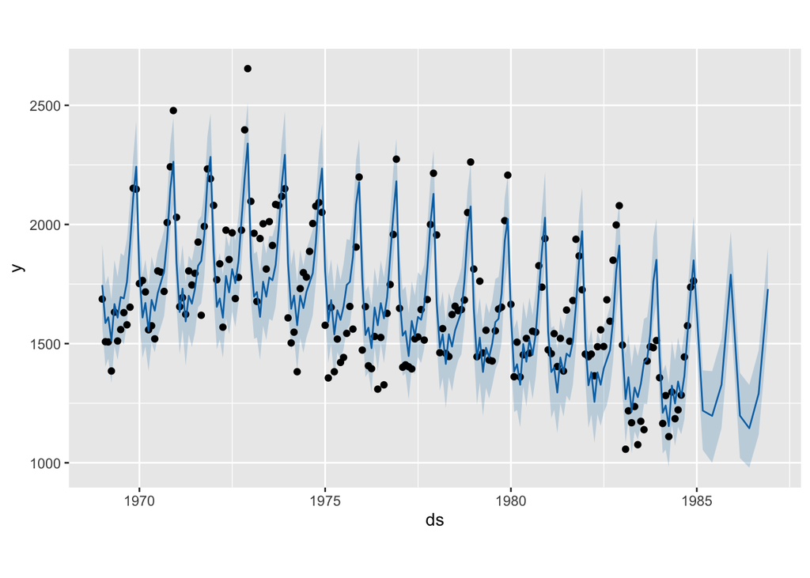

```r
plot(fitted_model,predict_future_deaths)
```

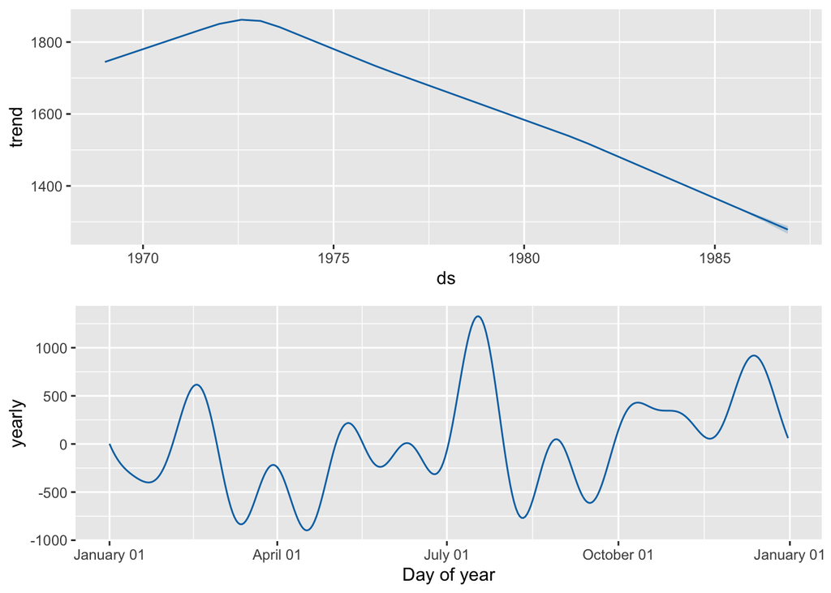

```r
prophet_plot_components(fitted_model,predict_future_deaths)
```

```r
ds = as.numeric(time(UKDriverDeaths))
y = as.numeric(UKDriverDeaths)

lm_model<- lm(ds~y, data = UKDriverDeaths)
summary(lm_model)
```

```
##
## Call:
## lm(formula = ds ~ y, data = UKDriverDeaths)
##
## Residuals:
##     Min      1Q  Median      3Q     Max
## -9.7539 -2.8528  0.2247  3.0932  8.8885
##
## Coefficients:
##               Estimate Std. Error  t value Pr(>|t|)
## (Intercept)  1.989e+03  1.758e+00 1131.615  < 2e-16 ***
## y           -7.170e-03  1.037e-03   -6.915 6.94e-11 ***
## ---
## Signif. codes:  0 '***' 0.001 '**' 0.01 '*' 0.05 '.' 0.1 ' ' 1
##
## Residual standard error: 4.15 on 190 degrees of freedom
## Multiple R-squared:  0.201,  Adjusted R-squared:  0.1968
## F-statistic: 47.81 on 1 and 190 DF,  p-value: 6.939e-11
```

I made the time series into a numeric function to be able to linearly model it. Then I used function summary to get a more simple explanation of my data. For example, from the estimates, we can clearly see that there is a negative correlation between ds (intercept) and y, suggesting that as time increases, the number of drivers killed or injured decreases.

```r
install.packages("astsa")
library(astsa)
```

The install.packages(“astsa”) function is to download the astsa package to be able to do the next part of the code and library to load the packages into the R session.

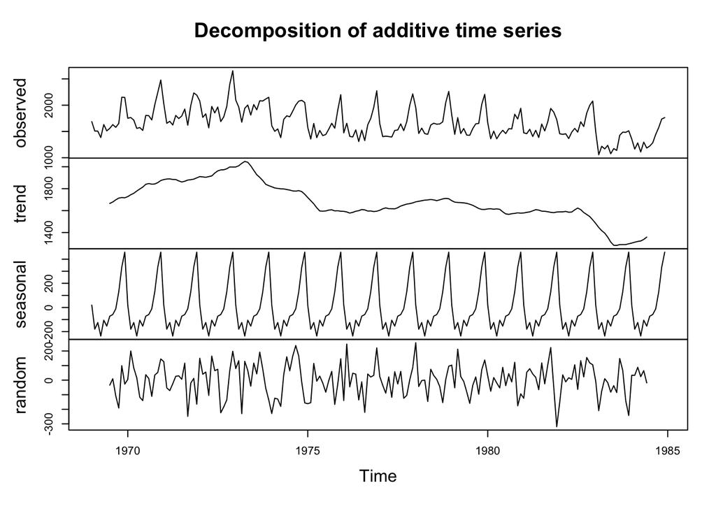

```r
model23 <-stats::decompose(UKDriverDeaths)
plot(model23)
```

The model23 is used for a time series decomposition into three main components, in this case random, seasonal and trend but as you can see there is an extra component called observed. Errors are spread around zero which makes it a good model. The trend time series shows how the number of drivers killed or injured has been decreasing.